# Assignment 7: Visualization - Some aspects of ggplot2

*How to do it?*:

- Open the Rmarkdown file of this assignment (link) in Rstudio.
- Right under each **question**, insert a code chunk (you can use the hotkey `Ctrl + Alt + I` to add a code chunk) and code the solution for the question.
- `Knit` the rmarkdown file (hotkey: `Ctrl + Alt + K`) to export an html.
- Publish the html file to your Githiub Page.

*Submission*: Submit the link on Github of the assignment to Canvas

### I. Questions on Your Selected Data

Use the data of your own. Produce the following types of plots and comment on each plot. Plots should be meaningful. If you use the data we used in class, make sure the plots are not the same as the ones in the slides. All plots should have title, caption, appropriate labels on x and y-axis.

```r
library(tidyverse)
df <- read_csv('data/titanic.csv')
```

1. Make a plot using `face_wrap` by one categorical variable (`face_wrap(~variable1)`)
2. Make a plot using `face_wrap` by two categorical variables (`face_wrap(variable1~variable2)`)
3. Make a plot using `position ='jitter'`.
4. Make a plot using `position ='dodge'`.
5. Make a plot using `position ='fill'`.
6. Make a plot using `geom_col`.
7. Change the theme of one of your plots.
8. Save a plot and put a link of the plot to your Github Webpage. To link a plot `abc.png` you just need to insert the following on the README.md

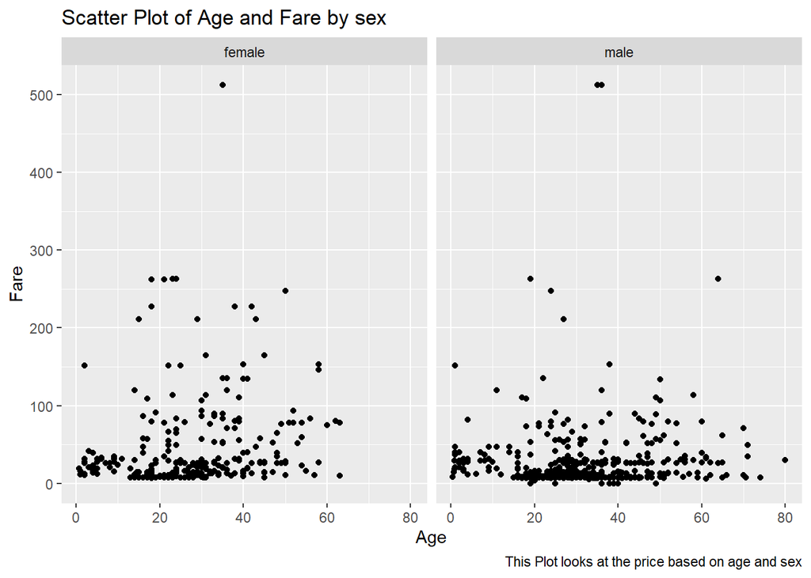

```r
#1. Make a plot using `face_wrap` by one categorical variable (`face_wrap(~variable1)`)
df %>%
  ggplot(mapping=aes(x=Age, y=Fare))+
  geom_point()+
  facet_wrap(~Sex)+
  labs(x='Age',
       y = 'Fare',
       title = 'Scatter Plot of Age and Fare by sex',
       caption = 'This Plot looks at the price based on age and sex')
```

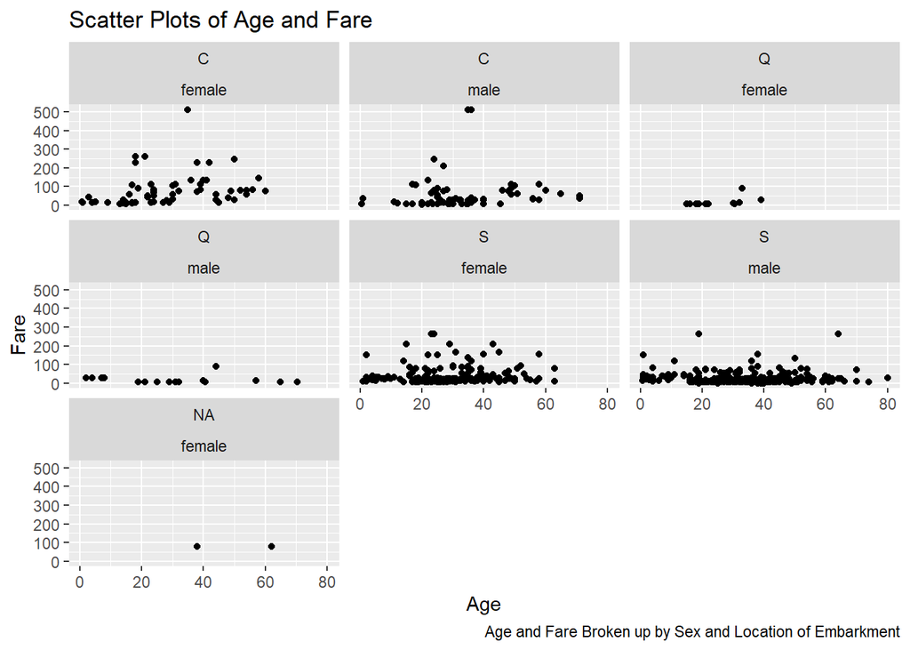

```r
#2. Make a plot using `face_wrap` by two categorical variables (`face_wrap(variable1~variable2)`)
df %>%
  ggplot(mapping=aes(x=Age, y=Fare))+
  geom_point()+
  facet_wrap(Embarked~Sex) +
  labs(x='Age',
       y = 'Fare',
       title = 'Scatter Plots of Age and Fare',
       caption = 'Age and Fare Broken up by Sex and Location of Embarkment')
```

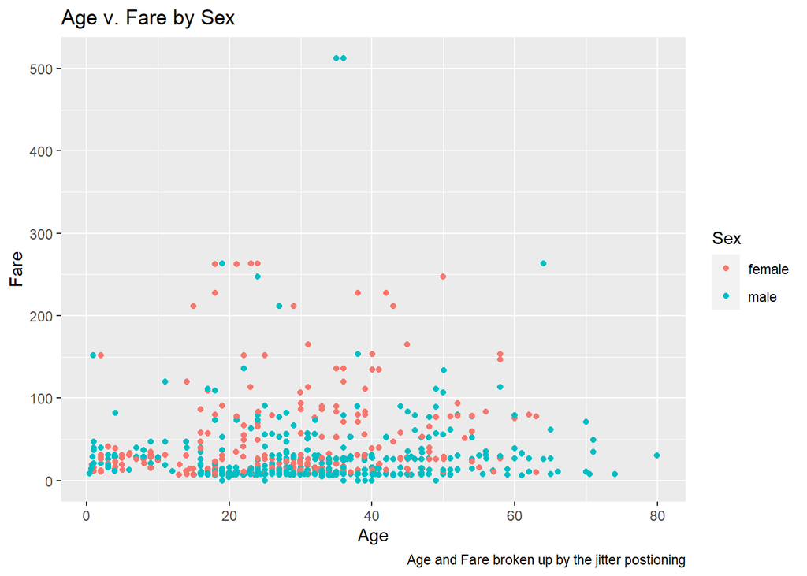

```r
#3. Make a plot using `position ='jitter'
df %>% ggplot()+
  geom_point(mapping=aes(x=Age, y=Fare, color=Sex),
             position='jitter')+
  labs(x='Age',
       y = 'Fare',
       title = 'Age v. Fare by Sex',
       caption = 'Age and Fare broken up by the jitter postioning')
```